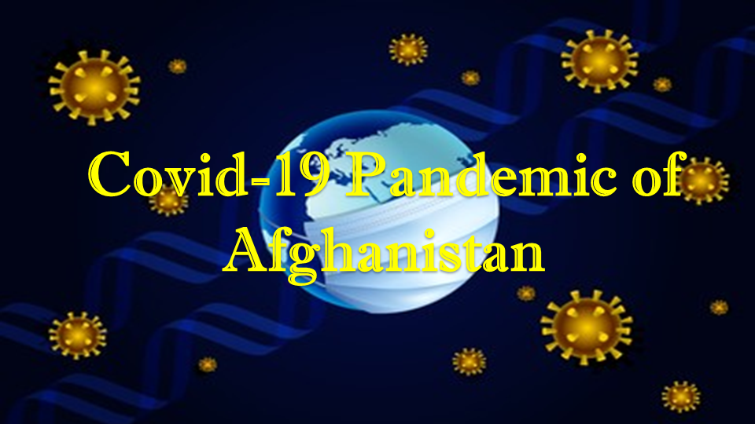

# *–Introduction–*

### About Afghanistan

Afghanistan, officially the Islamic Emirate of Afghanistan, is a landlocked country at the crossroads of Central and South Asia. It is bordered by Pakistan to the east and south, Iran to the west, Turkmenistan and Uzbekistan to the north, and Tajikistan and China to the northeast. Currently over 10 million youth and adults in Afghanistan are illiterate.

Afghanistan has four seasons, spring, summer, autumn and winter. The largest part of the country has a dry continental climate with hot summer and cold winter. In parts of the lowlands, especially in southern and eastern Afghanistan, the summer temperature can rise to 50 Celcius, but stays around 20 Celcius in the winter.In mountainous areas, winter temperatures may dip to -25 Celcius. In the higher mountain areas winter temperatures may even be considerably lower than that. Extensive snowfall is experienced in parts of the mountain region in the winter and many communities are isolated from the outside world for up to 4 months. Irrigated agriculture is largely dependent on their being enough snow in the mountains to melt in the spring. In many places, irrigated agriculture is totally dependent on sufficient snow in the mountains. The snow season is between October and April, but varies depending on altitude.

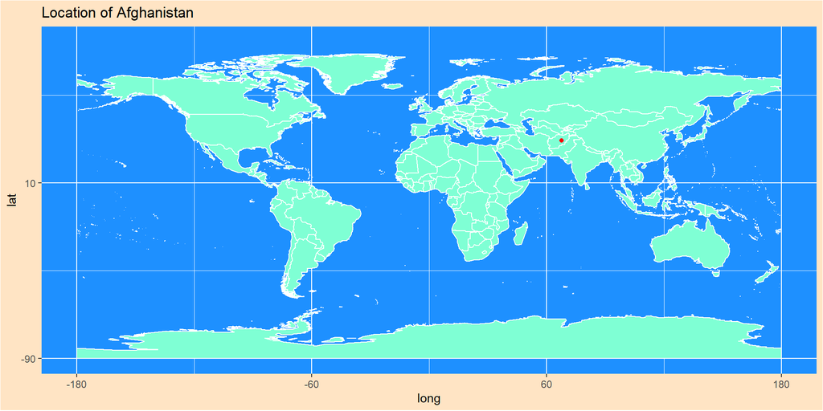

### Beginning of the covid-19 pandemic

The covid-19 pandemic is an ongoing global pandemic caused by severe acute respiratory syndrome coronavirus2. The novel virus was first defined in **Wuhan, China**, in December 2019. A lockdown in Wuhan and other cities in Hubei province Failed to contain the outbreak, and it spread to other parts of mainland China and around the world.The **World Health Organization (WHO)** declares a Public Health Emergency of International Concern on 30 January 2020, and a pandemic on 11 March 2020. Since 2021, variants of the virus have emerged and become dominant in many countries, with the **Delta**, **Alpha**, and **Beta** variants being the most virulent. As of 26 September 2021, more than **231 million** cases and **4.74 million** deaths have been confirmed, making it one of the deadliest pandemics in history.

### covid-19 situation in Afghanistan

Covid-19 pandemic was confirmed to have spread to Afghanistan when its index case, in Herat, was confirmed on 24 February 2020. On 27 March, it was announced that the Afghan cabinet had approved the lockdown of the capital of Afghanistan, Kabul, from 28 March for three weeks. On Saturday May 2, authorities extended the nationwide corona virus disease lockdown that was due to end Saturday, May 9 until Sunday May24. Lockdown measures in Kabul include a ban on inter-city travel, a reduction of all nonessential services, and the closure of nonessential businesses and public spaces. Individuals have also been asked not to venture outside. Government employees and those working in the health, food, telecommunication and media sectors are exempted from the restrictions, along with those shopping for basic necessities. Lock down measures vary on a province to province basis, though are generally based on the Kabul model. Food insecurity during the lockdown has been a major problem, with the government initiating a food distribution program to 250,000 poor families in Kabul. However, the UN estimates that as many as 14 million Afghans could face emergency levels of food insecurity if the crisis lasts until winter.

The number of covid-19 vaccination doses administered per 100 people in Afghanistan rose to eight as of September 25, 2021. This is counted as a single dose, and may not equal the total number of people vaccinated, depending on the specific dose regime.

# *–Exploratory Data Analysis–*

### *Daily Covid-19 confirmed cases in Afghanistan*

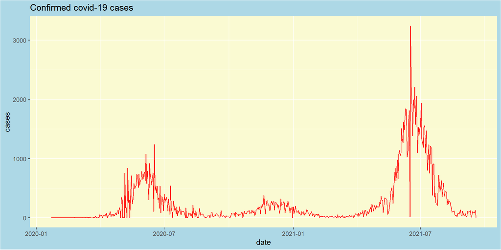

In the beginning of the year 2020, there are no confirmed cases recorded, but we can see,it takes a high value by June 2020. By August, that situation has dropped and there is no significant increase confirmed corona cases. But, by June 2021 it has begun to increase the number of cases have increased rapidly and around July 2021, it has taken a high value. However, by now that situation has greatly diminished.

### *Daily Covid-19 recovered cases in Afghanistan*

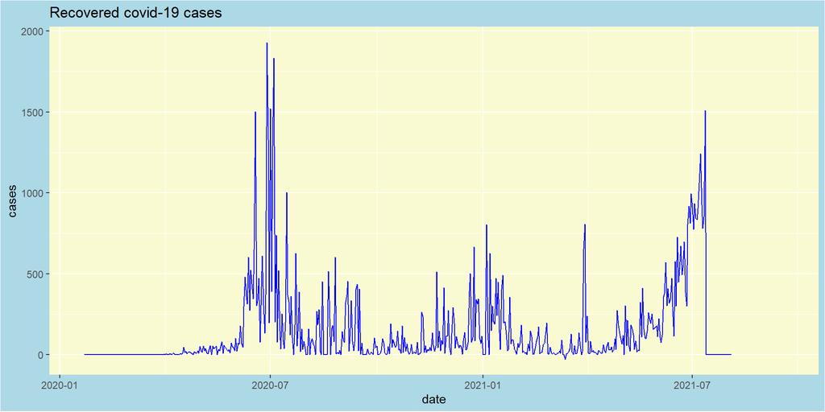

By July count of recovered cases has increased. It is in good condition. we can see increments as well as decrements of recovered cases in the above graph. After the month of July in 2021 there is no recording shown in the graph.

### *Daily Deaths of Afghanistan due to covid-19*

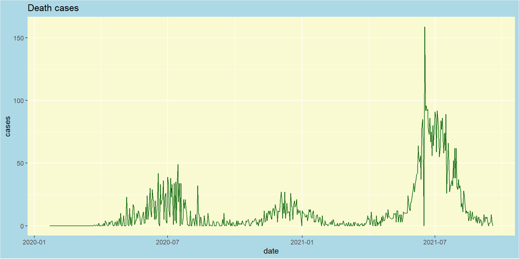

### *Summary of covid-19 cases in Afghanistan*

[figure not shown]

#### *Summary Statistics of covid-19 cases in Afghanistan*

```
      date              confirmed          death          recovered
 Min.   :2020-01-22   Min.   :  -2.0   Min.   :  0.00   Min.   : -28.0
 1st Qu.:2020-06-21   1st Qu.:  24.0   1st Qu.:  0.00   1st Qu.:   2.0
 Median :2020-11-19   Median :  84.0   Median :  4.00   Median :  38.0
 Mean   :2020-11-19   Mean   : 254.9   Mean   : 11.86   Mean   : 147.2
 3rd Qu.:2021-04-19   3rd Qu.: 261.5   3rd Qu.: 12.00   3rd Qu.: 160.0
 Max.   :2021-09-18   Max.   :3243.0   Max.   :159.00   Max.   :1930.0
                                                        NA's   :45
```

## *Comparison of the effect of covid-19 pandemic of Afghanistan with neighboring countries*

### *Comparison with our country, Sri Lanka*

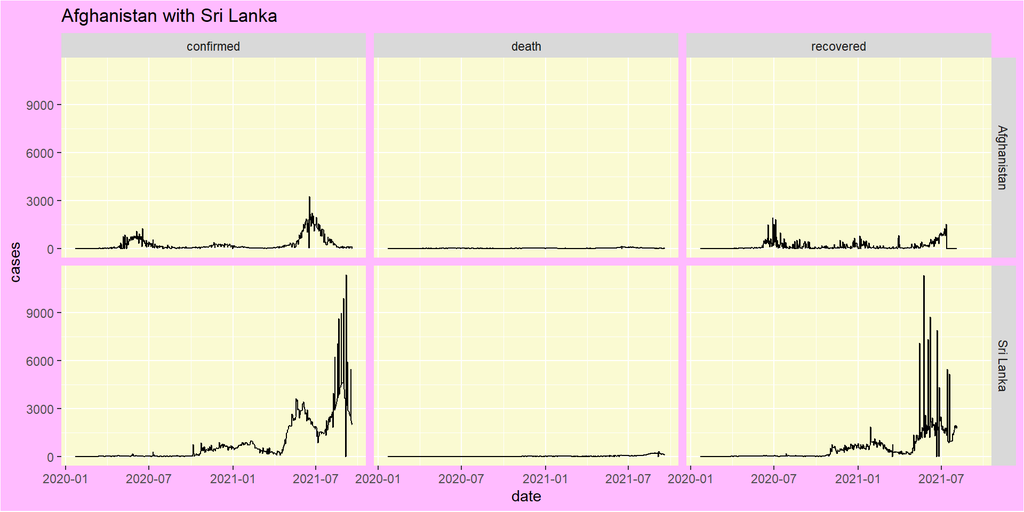

Afghanistan shows an significant increment of confirmed cases since about April in 2020, but Sri Lanka has started to shows an increment by October 2020. Afghanistan has reported their number of confirmed cases below 4,000. Even Sri Lanka takes a significant time period compared to Afghanistan to spread, within one year Sri Lanka has reported more than 10,000 confirmed cases. Corresponding recovered cases has increased over the time. Afghanistan shows significant death cases by July 2021 as well as death cases in Sri Lanka has increased after July 2021.

#### *Summary Statistics of covid-19 cases in Sri Lanka*

```
##       date              confirmed           death          recovered
##  Min.   :2020-01-22   Min.   :    0.0   Min.   :  0.00   Min.   :   -2.0
##  1st Qu.:2020-06-21   1st Qu.:    8.0   1st Qu.:  0.00   1st Qu.:    8.0
##  Median :2020-11-19   Median :  283.5   Median :  1.00   Median :   83.0
##  Mean   :2020-11-19   Mean   :  829.6   Mean   : 19.84   Mean   :  507.2
##  3rd Qu.:2021-04-19   3rd Qu.:  884.8   3rd Qu.:  7.00   3rd Qu.:  656.0
##  Max.   :2021-09-18   Max.   :11366.0   Max.   :334.00   Max.   :11340.0
##                                                          NA's   :45
```

### *Comparison with China*

- We can consider the China as the country of beginning this covid-19 pandemic. Furthermore, Afghanistan is bordered by China to the northeast.

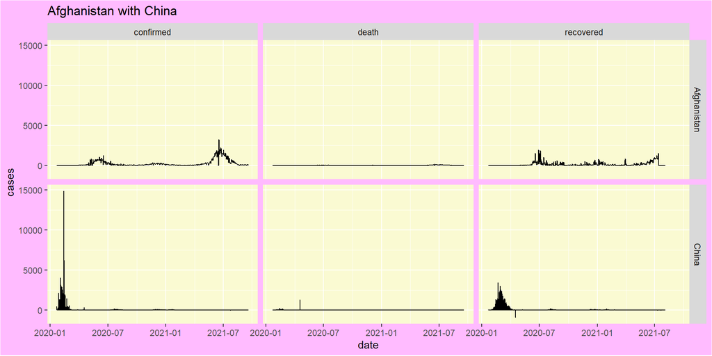

### *Comparison with Tajikistan*

- Tajikistan is the other country that located in northeast to the Afghanistan.

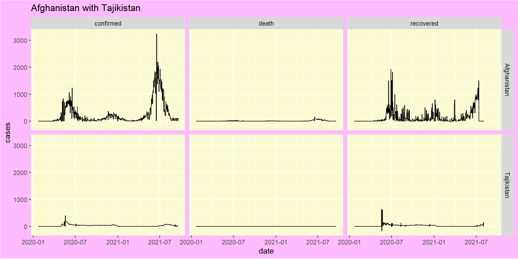

Around June in 2020, there is a high count of confirmed covid-19 cases. But it is not significant high campared to the Afghanistan. Since beginning, Tajikistan shows a count less than 1,000 in confirmed covid-19 cases. Compared to Afghanistan, Tajikistan is in good condition. we can see the count of deaths is almost less compared to the Afghanistan.

#### *Summary Statistics of covid-19 cases in Tajikistan*

```
##       date              confirmed          death          recovered
##  Min.   :2020-01-22   Min.   :  0.00   Min.   :0.0000   Min.   :-171.0
##  1st Qu.:2020-06-21   1st Qu.:  0.00   1st Qu.:0.0000   1st Qu.:   0.0
##  Median :2020-11-19   Median : 25.50   Median :0.0000   Median :   0.0
##  Mean   :2020-11-19   Mean   : 28.85   Mean   :0.2063   Mean   :  26.5
##  3rd Qu.:2021-04-19   3rd Qu.: 43.00   3rd Qu.:0.0000   3rd Qu.:  44.0
##  Max.   :2021-09-18   Max.   :407.00   Max.   :9.0000   Max.   : 641.0
##                                                         NA's   :45
```

### *Comparison with Pakistan*

- Pakistan is the country that bordered in Pakistan to the east and south of Afghanistan.

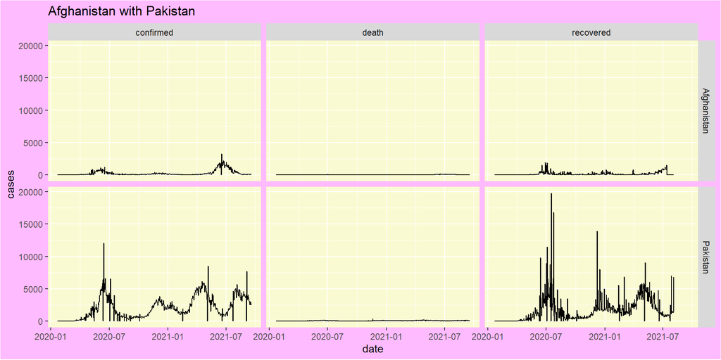

#### *Summary Statistics of covid-19 cases in Pakistan*

```
##       date              confirmed           death          recovered
##  Min.   :2020-01-22   Min.   :    0.0   Min.   :  0.00   Min.   :   -8
##  1st Qu.:2020-06-21   1st Qu.:  630.5   1st Qu.: 10.00   1st Qu.:  365
##  Median :2020-11-19   Median : 1640.5   Median : 39.00   Median : 1131
##  Mean   :2020-11-19   Mean   : 2019.5   Mean   : 44.89   Mean   : 1698
##  3rd Qu.:2021-04-19   3rd Qu.: 3084.0   3rd Qu.: 68.00   3rd Qu.: 2168
##  Max.   :2021-09-18   Max.   :12073.0   Max.   :313.00   Max.   :19772
##                                                          NA's   :45
```

### *Comparison with Iran*

- Afghanistan is bordered by Iran to the west.

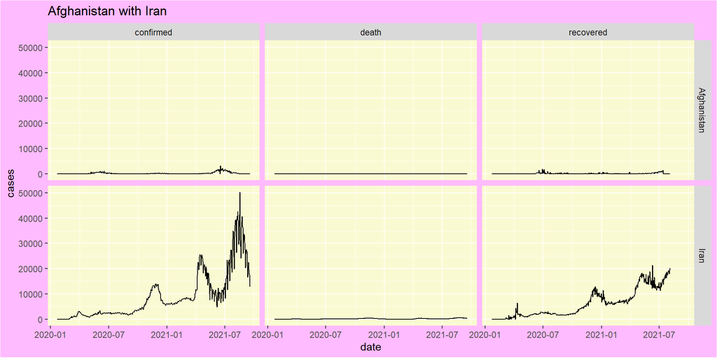

#### *Summary Statistics of covid-19 cases in Iran*

```
##       date              confirmed         death         recovered
##  Min.   :2020-01-22   Min.   :    0   Min.   :  0.0   Min.   :    0
##  1st Qu.:2020-06-21   1st Qu.: 2285   1st Qu.: 85.0   1st Qu.: 1819
##  Median :2020-11-19   Median : 6208   Median :142.5   Median : 4500
##  Mean   :2020-11-19   Mean   : 8926   Mean   :192.7   Mean   : 6140
##  3rd Qu.:2021-04-19   3rd Qu.:11707   3rd Qu.:252.8   3rd Qu.: 9306
##  Max.   :2021-09-18   Max.   :50228   Max.   :709.0   Max.   :21409
##                                                       NA's   :45
```

### *Comparison with Uzbekistan*

- Afghanistan is bordered by Turkmenistan and Uzbekistan to the north. Following graph shows the comparison of covid-19 pandemic of Afghanistan and Uzbekistan.

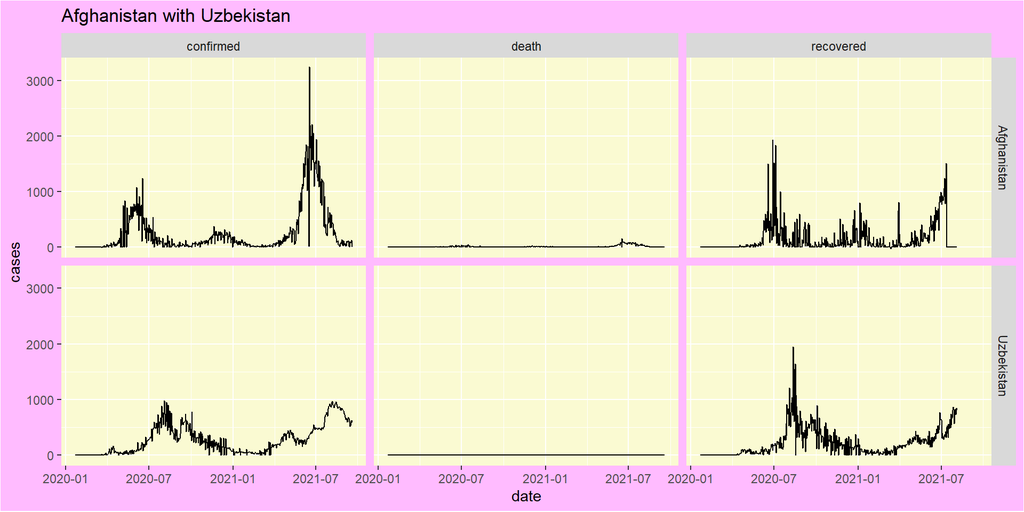

We can see the beginning of the pandemic has occurred approximately at the same time. In June 2020 Afghanistan has recorded high confirmed covid-19 cases exceeded 1,000 , but the number of recorded cases has decreased by August 2020. Compared to Afghanistan, Uzbekistan has taken that whole time period to close 1,000. Uzbekistan is not exceeded the number of covid-19 confirmed cases than 1,000 , but Afghanistan has exceeded 3,000. Uzbekistan shows a less count of deaths due to pandemic than Afghanistan up to now.

#### *Summary Statistics of covid-19 cases in Uzbekistan*

```
##       date              confirmed         death         recovered
##  Min.   :2020-01-22   Min.   :  0.0   Min.   :0.000   Min.   :   0.0
##  1st Qu.:2020-06-21   1st Qu.: 51.0   1st Qu.:0.000   1st Qu.:  36.0
##  Median :2020-11-19   Median :208.5   Median :1.000   Median : 151.0
##  Mean   :2020-11-19   Mean   :277.0   Mean   :1.954   Mean   : 225.3
##  3rd Qu.:2021-04-19   3rd Qu.:446.0   3rd Qu.:4.000   3rd Qu.: 324.0
##  Max.   :2021-09-18   Max.   :981.0   Max.   :9.000   Max.   :1955.0
##                                                       NA's   :45
```

# *–Conclusions–*

- Pandemic has begun to spread in Afghanistan after some months from the beginning of the pandemic in China.
- Daily covid-19 confirmed count has exceeded 3,000 in some days about after one year since beginning.
- Most of the time in this time period, Afghanistan has controlled their number of confirmed cases below 1,000.
- There is a good progress in recovering compared to confirmed cases.
- Apart few months around July in 2021, they have controlled the number of deaths occurred in a low value. We can consider it as a good condition.
- When comparing the pandemic of Afghanistan with some neighboring countries, there are some cases that the facing of Afghanistan against this pandemic is good as well as some cases are bad.

# *–Discussion–*

Coronavirus disease 2019, in short COVID-19 is a new virus discovered in recent time. This virus has made a lot of people sick. Doctors and relevant institutions are still studying about this. Doctors and officers related to health are work with dedication to control this pandemic, and working hard to help people stay healthy. It should be give our support as well to them. We can practice healthy habits at home, workplaces and any other public place to help prevent spread of covid-19. As some of them we can do following things easily ;

- Cough or sneeze into a tissue and throw back it in the dustbin right away.
- Keep hands out of eyes, nose, face and mouth to keep germs out of the body.
- Avoid crowded places and stay six feet away from one another and avoid touching surfaces in public places.
- Wash hands with soap and water for at least 20 seconds, or else we can use hand sanitizer to clean the germs.
- When we feel some sick with cough and fever, limit connecting with society and stay home.

Covid-19 can effect in different ways. Some people do not show any different even they get positive result from from a covid-19 test. Some people may show fever, cough or have a hard taking breaths. This has effected highly for people who are still have impact from other diseases like heart related diseases.

This pandemic has impacted to people in many ways. We can consider following few things as some of them.

- Downward trends of family economic conditions and several lower hierarchy social classes facing unbearable economic hardships due to lack of daily or monthly earning. There are many people who are losing their jobs and incomes.
- There have closed schools, universities and education institutes still. In most education has gone down by now.
- Some people may face various kind of stress and depression conditions due to malfunction of the social system.

There are some advantages as well due to this pandemic.

- People have learnt about ideal social behaviours.
- People attracted to traditional foods consumption practices mainly based on the family. People grew their own vegetables as well.
- Reduction in plastic and polythene use at the domestic level, thus reducing the environmental pollution. Mainly, air, sound and water pollution have reduced. Perhaps, there may be some climate changes in the environment.

Safe and effective vaccines are an important way to protect people against covid-19. National regulatory authorities have granted emergency use authorizations for 23 covid-19 vaccines. There are seven vaccines approved for use by WHO. They are Moderna, Pfizer/BioNTech, Janssen, Oxford/AstraZenica, Covishield, Sinopharm, and Sinovax. Being vaccinated does not mean that there is no risk of infection of coronavirus, because researches are still ongoing.

### *–References–*

https://www.who.int

https://www.en.m.wikipedia.org

https://hellor.netlify.app/slides/coronavirus_assignment_help_file

https://hellor.netlify.app/coronareports/

[figure not shown]